# Package prep

Timothee Bonnet

22 June 2020

## Why create your own R-packages?

- Increases reproducibility
- Forces you to clean, check and document your code; which removes many mistakes and problems.
- Simple to do but looks so cool.
- Opens the door to putting packages along publications, Github, CRAN and be recognized and cited for your programming work.

## Packages you will need to create packages easily

Install if you do not have them already.

```r
library(devtools)
library(roxygen2)
```

> Note: there are several pipelines to create packages, some using directly RStudio tools. I chose to demonstrate using a pipeline that relies mostly on code and little on clicking buttons, because the former is more reproducible.

## Getting started

Start a R session from a parent directory in which you want to create your package. The package will be initialized inside a new directory. This new directory will also be a new RStudio project.

We will create a package that contains a few functions to handle temperature data. Our package will simply be called “temperature”.

Let’s initialize the package:

```r
create("temperature")
```

Check the content of the new directory “temperature”:

- **A folder “R”, currently empty. We will store our R-functions in there.**
- A file DESCRIPTION. Meta-data about your package.
- A file NAMESPACE. Handle relationships with other packages. Do not modify by hand. Not that important if you’re only developing packages for yourself; very important if you plan to share.
- An RStudio project file “temperature.Rproj”. Don’t worry about it.

```r
fahr_to_kelvin <- function(temp) {
  stopifnot(is.numeric(temp))
  kelvin <- ((temp - 32) * (5 / 9)) + 273.15
  return(kelvin)
}

kelvin_to_celsius <- function(temp) {
  celsius <- temp - 273.15
  return(celsius)
}

celsius_to_kelvin <- function(temp) {
  kelvin <- temp + 273.15
  return(kelvin)
}
```

You can create this file by hand or use some code:

```r
sink(file = "R/Functions.R")
cat("fahr_to_kelvin <- function(temp) {
  stopifnot(is.numeric(temp))
  kelvin <- ((temp - 32) * (5 / 9)) + 273.15
  return(kelvin)
}

kelvin_to_celsius <- function(temp) {
  celsius <- temp - 273.15
  return(celsius)
}

celsius_to_kelvin <- function(temp) {
  kelvin <- temp + 273.15
  return(kelvin)
}
")
sink()
```

Now we can load the functions and get ready to install your package:

```r
load_all(".")
```

```
## Loading temperature
```

```r
document(".")
```

For now `document()` only created the empty directory `man/` and nothing else. That is because there was nothing to document yet.

Now we can install the package from the parent directory:

```r
install("../temperature")
```

Your package already appears in R-Studio Package tab and can be used. However, there is not much information about the package and its functions.

Our functions are not accessible in R:

```r
fahr_to_kelvin(10)
```

And there is no information about them:

```r
?fahr_to_kelvin
```

Let’s add more information to our package using Roxygen syntax. First for the `fahr_to_kelvin` function:

```r
#' Fahrenheit to Kelvin conversion
#'
#' This function takes a temperature expressed in Fahrenheit and convert it to Kelvin.
#' @param temp A temperature expressed in Fahrenheit
#'
#' @export
fahr_to_kelvin <- function(temp) {
  stopifnot(is.numeric(temp))
  kelvin <- ((temp - 32) * (5 / 9)) + 273.15
  return(kelvin)
}
```

The `@export` line is critical. This tells Roxygen2 to add this function to the NAMESPACE file, so that it will be accessible to users. For your first R package, you’ll probably want to include `@export` for each of your functions (in large packages it is sometimes a good idea to hide some functions that are used only internally by other functions).

Now let’s repeat the process:

```r
load_all(".")
document(".")
```

Notice that the NAMESPACE file has changed.

This time a file has been created in `/man`

```r
install("../temperature")
```

And we can reach our function help page and run the function:

```r
?fahr_to_kelvin
fahr_to_kelvin(10)
```

You can see that it is still missing some usual components that are for instance on the `mean()` help page: Value, References, See Also, Examples…

```r
#' Fahrenheit to Kelvin conversion
#'
#' This function takes a temperature expressed in Fahrenheit and convert it to Kelvin.
#' @param temp A temperature expressed in Fahrenheit
#'
#' @return A temperature in Kelvin
#'
#' @examples
#' fahr_to_kelvin(32)
#'
#' @export
fahr_to_kelvin <- function(temp) {
  stopifnot(is.numeric(temp))
  kelvin <- ((temp - 32) * (5 / 9)) + 273.15
  return(kelvin)
}
```

```r
load_all(".", reset = TRUE)
document(".")
install("../temperature", reload = TRUE)
```

```r
library(temperature)
?fahr_to_kelvin
fahr_to_kelvin(temp = )
```

By the way, sometimes you need to restart your R-session between installations for RStudio to be able to find help pages.

> Now create documentation for `kelvin_to_celsius()`, re-install the package and check you can access the new help page.

```r
#' Kelvin to Celsius conversion
#'
#' This function takes a temperature expressed in Kelvin and convert it to Celsius.
#'
#' @param temp A temperature expressed in Kelvin
#'
#' @return A temperature in Celsius.
#'
#' @examples
#' kelvin_to_celsius(300)
#'
#' @export
kelvin_to_celsius <- function(temp) {
  celsius <- temp - 273.15
  return(celsius)
}
```

### Initial fill of the DESCRIPTION

```r
Package: temperature
Title: Utilities to handle temperature data
Version: 0.0.1
Authors@R:
    person(given = "Timothée",
           family = "Bonnet",
           role = c("aut", "cre"),
           email = "timotheebonnetc@gmail.com",
           comment = c(ORCID = "0000-0001-7186-5288"))
Description: What the package does (one paragraph).
License: GPL-3
Encoding: UTF-8
LazyData: true
Roxygen: list(markdown = TRUE)
RoxygenNote: 7.1.0
```

## More complete build

```r
#roxygenise(".", clean = TRUE)
load_all(".")
document(".")
build(pkg = ".", manual = TRUE)
check(".", manual = TRUE )
install("../temperature", reload = TRUE)
```

Check is very useful. Always try to get 0 errors, 0 warnings, 0 notes.

More complete documentation:

```r
build_manual()
build_readme()
build_site()
```

At a later stage consider creating vignettes (i.e. tutorials, examples…)

```r
build_vignettes()
```

## Add data

Temperature data from Tuggeranong 1997-2019 http://www.bom.gov.au/climate/data/

```r
download.file("https://timotheenivalis.github.io/data/tuggeranong.csv",
              destfile = "tuggeranong.csv")
tuggeranong <- read.csv("tuggeranong.csv")
```

Initialize the dataset

```r
use_data(tuggeranong, overwrite = TRUE)
```

We need to document the dataset. The documentation goes into the `/R` folder in a file called `data.R`.

```r
sink("R/data.R")
cat("
#' Mean maximum temperature (monthly average) at Tuggeranong
#'
#' A dataset containing the average mean maximum temperature per month from 1997 to 2019.
#'
#' @format A data frame with 23 rows and 13 variables:
#' \\describe{
#'   \\item{Year}{Year}
#'   \\item{Jan}{January mean maximum temperature}
#'   \\item{Feb}{February mean maximum temperature}
#'   \\item{Mar}{March mean maximum temperature}
#'   \\item{Apr}{April mean maximum temperature}
#'   \\item{May}{May mean maximum temperature}
#'   \\item{Jun}{June mean maximum temperature}
#'   \\item{Jul}{July mean maximum temperature}
#'   \\item{Aug}{August mean maximum temperature}
#'   \\item{Sep}{September mean maximum temperature}
#'   \\item{Oct}{October mean maximum temperature}
#'   \\item{Nov}{November mean maximum temperature}
#'   \\item{Dec}{December mean maximum temperature}
#'   ...
#' }
#' @source \\url{http://www.bom.gov.au/climate/data/}
\"tuggeranong\"
")
sink()
```

Don’t use `@export` for a dataset. The export is automatic.

```r
#roxygenise(".", clean = TRUE)
load_all(".")
document(".")
build(pkg = ".", manual = TRUE)
check(".", manual = TRUE )
install("../temperature", reload = TRUE)
```

```r
library(temperature)
data("tuggeranong")
tuggeranong
```

```
##    Year  Jan  Feb  Mar  Apr  May  Jun  Jul  Aug  Sep  Oct  Nov  Dec
## 1  1997 27.2 30.4 24.8 23.0 16.7 12.8 12.2 13.9 16.1 21.7 26.9 29.9
## 2  1998 29.5 30.5 27.8 21.4 16.2 12.8 11.2 13.7 17.7 18.7 21.4 27.8
## 3  1999 29.5 27.1 25.1 19.0 17.8 12.6 13.3 14.9 18.1 20.2 20.9 24.9
## 4  2000 25.1 29.2 25.7 20.4 15.1 12.6 11.9 13.5 18.2 19.5 22.8 28.0
## 5  2001 31.2 29.0 23.7 21.3 16.6 14.3 12.6 13.7 18.8 18.9 22.4 26.5
## 6  2002 28.7 24.5 25.5 22.6 16.2 13.4 12.8 14.9 17.9 21.7 27.7 28.4
## 7  2003 30.6 29.2 23.9 20.1 17.2 13.2 12.5 13.3 16.8 17.9 24.4 27.6
## 8  2004 29.5 30.5 27.0 22.1 16.5 13.1 12.1 14.6 17.5 20.3 23.7 26.4
## 9  2005 28.8 27.0 24.5 24.3 18.3 13.9 12.7 14.5 16.4 20.4 22.9 28.8
## 10 2006 30.6 30.5 27.0 19.6 16.1 11.8 12.5 15.4 19.3 24.0 26.4 27.7
## 11 2007 30.8 28.3 25.8 22.0 17.9 11.6 11.4 15.2 17.4 23.0 24.8 25.1
## 12 2008 29.2 24.5 26.0 19.6 17.2 14.5 11.6 13.0 18.3 23.1 23.1 24.9
## 13 2009 31.3 28.9 26.6 19.6 16.4 12.4 12.6 14.7 17.6 18.8 28.8 29.0
## 14 2010 31.6 27.2 24.9 21.4 16.6 13.3 12.8 12.5 16.7 19.7 22.5 24.9
## 15 2011 28.7 26.5 23.3 19.4 15.3 13.4 12.2 15.8 17.9 20.3 25.0 23.4
## 16 2012 26.8 24.7 22.1 20.2 15.5 12.7 12.7 13.5 18.0 20.9 25.3 27.2
## 17 2013 32.0 26.8 25.1 21.8 16.8 13.4 12.7 14.3 19.7 21.9 23.7 28.5
## 18 2014 31.2 28.9 24.1 19.3 17.4 13.0 12.1 13.9 17.8 22.7 27.3 27.3
## 19 2015 26.9 27.1 25.6 18.5 16.0 13.3 10.9 13.4 17.2 24.8 24.4 28.6
## 20 2016 27.7 29.1 26.8 23.4 17.2 12.8 12.6 14.2 15.7 18.5 25.0 28.1
## 21 2017 31.9 29.6 25.5 19.6 16.2 13.4 12.7 13.6 17.8 22.6 23.8 27.4
## 22 2018 31.0 28.3 26.3 24.9 17.3 13.0 13.3 13.7 17.9 22.4 24.1 29.1
## 23 2019 34.1 28.9 25.6 22.5 16.4 13.7 13.6 14.1 18.6 23.3 26.2 31.2
```

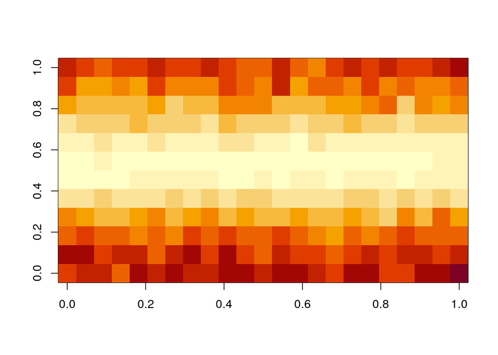

```r
image(as.matrix(tuggeranong[,-1]))
```

At least two reasons to include data in your package:

1. Give realistic input to examples in your function documentation
2. Share data along your analyses so that analyses can be reproduced and improved

## Connect to other packages

So far our package only uses R-base code. However we could write fancier functions if we used code already available in other packages.

Let’s try to include this function in the package:

```r
Wide_To_Long_Temperature <- function(dat, id.vars="Year",
                                variable.name = "Month",
                                value.name = "Temperature"){
  require(reshape2)
  stopifnot(expr={is.data.frame(dat)
    id.vars %in% colnames(dat)
    })
  melttemp <- melt(dat, id.vars = id.vars,
                 variable.name = variable.name,
                 value.name = value.name)
  return(melttemp)
}

Wide_To_Long_Temperature(tuggeranong)
```

```
##     Year Month Temperature
## 1   1997   Jan        27.2
## 2   1998   Jan        29.5
## 3   1999   Jan        29.5
## 4   2000   Jan        25.1
## 5   2001   Jan        31.2
## 6   2002   Jan        28.7
## 7   2003   Jan        30.6
## 8   2004   Jan        29.5
## 9   2005   Jan        28.8
## 10  2006   Jan        30.6
## 11  2007   Jan        30.8
## 12  2008   Jan        29.2
## 13  2009   Jan        31.3
## 14  2010   Jan        31.6
```

[output cut: 262 more lines]

```r
#' Wide to long conversion for standard monthly temperature
#'
#' This function takes a standard monthly temperature dataframe in wide format to long format.
#'
#' @param dat A temperature dataframe
#' @param id.vars Character string. vector of id variables. Can be integer (variable position) or string (variable name). If blank, will use all non-measured variables.
#' @param variable.name Character string. Nname of variable used to store measured variable names
#' @param value.name Character string. Name of variable used to store values
#'
#' @return A dataframe
#'
#' @examples
#' data("tuggeranong")
#' Wide_To_Long_Temperature(tuggeranong)
#'
#' @export
Wide_To_Long_Temperature <- function(dat, id.vars="Year",
                                     variable.name = "Month",
                                     value.name = "Temperature"){
  require(reshape2)
  stopifnot(expr={is.data.frame(dat)
    id.vars %in% colnames(dat)
  })
  melttemp <- melt(dat, id.vars = id.vars,
                   variable.name = variable.name,
                   value.name = value.name)
  return(melttemp)
}
```

```r
load_all()
document()
check()
```

We get a warning message. Never use library() or require() in a R package!

Two things to do:

1. In DESCRIPTION add:

   ```
   Imports:
   reshape2
   ```

2. In your function change `melt` to `reshape2::melt`

```r
load_all()
```

```
## Loading temperature
```

```r
document()
```

```
## Updating temperature documentation
## Loading temperature
```

```
## Writing NAMESPACE
## Writing NAMESPACE
```

```r
check()
```

```
## Updating temperature documentation
## Loading temperature
```

```
## Warning:
## x Wide_To_Long_Temperature() masks temperature::Wide_To_Long_Temperature()
##
## Did you accidentally source a file rather than using `load_all()`?
## Run `rm(list = c("Wide_To_Long_Temperature"))` to remove the conflicts.
```

[output not shown]

[output cut: 46 more lines]

```
## * checking for code/documentation mismatches ... OK
## * checking Rd \usage sections ... OK
## * checking Rd contents ... OK
## * checking for unstated dependencies in examples ... OK
## * checking contents of ‘data’ directory ... OK
## * checking data for non-ASCII characters ... OK
## * checking data for ASCII and uncompressed saves ... OK
## * checking examples ... OK
## * checking for detritus in the temp directory ... OK
## * DONE
##
## Status: 1 NOTE
## See
##   ‘/tmp/RtmpoR7D94/temperature.Rcheck/00check.log’
## for details.
```

```
## ── R CMD check results ────────────────────────────────── temperature 0.0.1 ────
## Duration: 9.8s
##
## > checking top-level files ... NOTE
##   Non-standard file/directory found at top level:
##     ‘preparation_files’
##
## 0 errors ✓ | 0 warnings ✓ | 1 note x
```

No more warnings!

Now practice by adding the function below to your package:

```r
plot_trend <- function(dat=tuggeranong){
  melttemp <- Wide_To_Long_Temperature(dat)

  model <- summary(lm(Temperature ~ Year + Month, data = melttemp))
  year_effect <- round(model$coefficients["Year",],3)

  library(ggplot2)
  ggplot(data=melttemp,
         aes(x=Year,y=Temperature, color=Month))+
    geom_point() + geom_smooth(alpha=0.2) +
    annotate("label", x = mean(melttemp$Year),
             y = max(melttemp$Temperature),
             label = paste0(ifelse(year_effect[1]>=0, "+", "-"),
                            year_effect[1], "°C/year, p=",year_effect[4]))
}
```

## Make the package a GitHub repository and install from github

If you already have a Github account create a new repo for your package. You can leave the repository completely empty during initialization.

```
echo "# temperature" >> README.md
git init
git add README.md
git commit -m "first commit"
git remote add origin https://github.com/timotheenivalis/temperature.git
git push -u origin master
```

```
git add data/ man/ R/ NAMESPACE DESCRIPTION .gitignore .Rbuildignore
git commit -m "load all package files"
git push
```

Now people can install your package from github. If you want to see my final code, it is there!

```r
install_github("timotheenivalis/temperature")
```

[output not shown]

## More information

R packages book by Hadley Wickham: http://r-pkgs.had.co.nz/intro.html